# SR_02_RLTD_ORG_ADDR_CITY

Related organization city · Text report

## Overview

**Description**

Address Foreign - City

**Table**

`SR-P02-T01-ID-RLTD-TAX-EXEMPED-ORGS` (many)

**Location code**

`SCHED-R-PART-02-COL-A`

**Family**

`SCHED-R-PART-02-COL-A` · siblings: SR_02_RLTD_ORG_ADDR_CNTR, SR_02_RLTD_ORG_ADDR_L1, SR_02_RLTD_ORG_ADDR_L2, SR_02_RLTD_ORG_ADDR_STATE, SR_02_RLTD_ORG_ADDR_ZIP, SR_02_RLTD_ORG_EIN

**Data type**

text (xsd: TextType, CityType)

**Scope**

PC

**Status**

unreviewed

6

xpaths mapped (6 observed)

845,166

filings with a value

2009–2024

tax years observed

3

open flags (1 errors)

## Flags

| Severity | Flag | Xpath | Detail |
| --- | --- | --- | --- |
| ⚠ error | `COLLISION` | IRS990ScheduleR/IdRelatedTaxExemptOrgGrp/ForeignAddress/CityNm | 6737 filings contain 2+ of its xpaths; most common set: /Return/ReturnData/IRS990ScheduleR/IdRelatedTaxExemptOrgGrp/ForeignAddress/CityNm ; /Return/ReturnData/IRS990ScheduleR/IdRelatedTaxExemptOrgGrp/… |
| ⓘ info | `MANY_NOT_REPEATING` | IRS990ScheduleR/IdRelatedTaxExemptOrgGrp/USAddress/CityNm | many-to-one table, but 52% of values sit in no repeating element |
| ⓘ info | `MANY_NOT_REPEATING` | IRS990ScheduleR/IdRelatedTaxExemptOrgGrp/USAddress/City | many-to-one table, but 50% of values sit in no repeating element |

## Xpaths

All mapped xpaths (under /Return/ReturnData or /Return/ReturnHeader), oldest first. Charts label each series by its xpath.

| Xpath | Form | Chart label | First year | Last year | Versions | Filings | Repeats in |
| --- | --- | --- | --- | --- | --- | --- | --- |
| IRS990ScheduleR/Form990ScheduleRPartII/AddressUS/City | Sched R | same | 2009 | 2012 | 18 | 132,312 | 51.3% |
| IRS990ScheduleR/Form990ScheduleRPartII/AddressForeign/City | Sched R | same | 2009 | 2012 | 15 | 1,584 | 29.4% |
| IRS990ScheduleR/IdRelatedTaxExemptOrgGrp/USAddress/City | Sched R | same | 2013 | 2013 | 3 | 47,596 | 49.2% |
| IRS990ScheduleR/IdRelatedTaxExemptOrgGrp/ForeignAddress/City | Sched R | same | 2013 | 2013 | 3 | 643 | 28.6% |
| IRS990ScheduleR/IdRelatedTaxExemptOrgGrp/USAddress/CityNm | Sched R | same | 2014 | 2024 | 34 | 651,290 | 47.9% |
| IRS990ScheduleR/IdRelatedTaxExemptOrgGrp/ForeignAddress/CityNm | Sched R | …0ScheduleR/IdRelatedTaxExemptOrgGrp/ForeignAddress/CityNm | 2014 | 2024 | 34 | 11,741 | 31.4% |

## Coverage

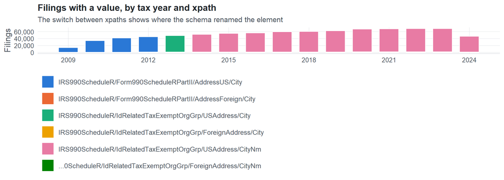

**Table view**

Table view: filings by tax year and series

| Tax year | IRS990ScheduleR/Form990ScheduleRPartII/AddressUS/City | IRS990ScheduleR/Form990ScheduleRPartII/AddressForeign/City | IRS990ScheduleR/IdRelatedTaxExemptOrgGrp/USAddress/City | IRS990ScheduleR/IdRelatedTaxExemptOrgGrp/ForeignAddress/City | IRS990ScheduleR/IdRelatedTaxExemptOrgGrp/USAddress/CityNm | …0ScheduleR/IdRelatedTaxExemptOrgGrp/ForeignAddress/CityNm |
| --- | --- | --- | --- | --- | --- | --- |
| 2009 | 13,294 | 156 | 0 | 0 | 0 | 0 |
| 2010 | 33,609 | 376 | 0 | 0 | 0 | 0 |
| 2011 | 40,919 | 492 | 0 | 0 | 0 | 0 |
| 2012 | 44,490 | 560 | 0 | 0 | 0 | 0 |
| 2013 | 0 | 0 | 47,596 | 643 | 0 | 0 |
| 2014 | 0 | 0 | 0 | 0 | 51,116 | 734 |
| 2015 | 0 | 0 | 0 | 0 | 53,523 | 811 |
| 2016 | 0 | 0 | 0 | 0 | 55,448 | 860 |
| 2017 | 0 | 0 | 0 | 0 | 58,874 | 976 |
| 2018 | 0 | 0 | 0 | 0 | 59,172 | 1,061 |
| 2019 | 0 | 0 | 0 | 0 | 60,848 | 1,146 |
| 2020 | 0 | 0 | 0 | 0 | 65,651 | 1,262 |
| 2021 | 0 | 0 | 0 | 0 | 66,652 | 1,287 |
| 2022 | 0 | 0 | 0 | 0 | 67,472 | 1,348 |
| 2023 | 0 | 0 | 0 | 0 | 67,375 | 1,362 |
| 2024 | 0 | 0 | 0 | 0 | 45,159 | 894 |

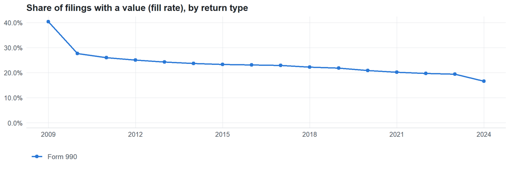

**Table view**

Table view: fill rate

| Tax year | Return type | Filings | All filings | Fill rate |
| --- | --- | --- | --- | --- |
| 2009 | Form 990 | 13,450 | 33,311 | 40.38% |
| 2010 | Form 990 | 33,985 | 123,025 | 27.62% |
| 2011 | Form 990 | 41,411 | 159,504 | 25.96% |
| 2012 | Form 990 | 45,050 | 179,688 | 25.07% |
| 2013 | Form 990 | 48,239 | 198,855 | 24.26% |
| 2014 | Form 990 | 51,850 | 218,619 | 23.72% |
| 2015 | Form 990 | 54,334 | 233,519 | 23.27% |
| 2016 | Form 990 | 56,308 | 243,903 | 23.09% |
| 2017 | Form 990 | 59,850 | 261,612 | 22.88% |
| 2018 | Form 990 | 60,233 | 271,442 | 22.19% |
| 2019 | Form 990 | 61,994 | 283,694 | 21.85% |
| 2020 | Form 990 | 66,913 | 320,342 | 20.89% |
| 2021 | Form 990 | 67,939 | 336,480 | 20.19% |
| 2022 | Form 990 | 68,820 | 349,055 | 19.72% |
| 2023 | Form 990 | 68,737 | 354,768 | 19.38% |
| 2024 | Form 990 | 46,053 | 277,298 | 16.61% |

## Repeating groups

Table cardinality in the concordance: **many**. 6 of 6 observed xpaths repeat within a filing.

Repeating element each xpath was observed in (from the raw indexed xpath)

| Xpath | Repeating element | Filings (summed over years) |
| --- | --- | --- |
| IRS990ScheduleR/Form990ScheduleRPartII/AddressForeign/City | (none) | 535 |
| IRS990ScheduleR/Form990ScheduleRPartII/AddressForeign/City | IRS990ScheduleR/Form990ScheduleRPartII | 1049 |
| IRS990ScheduleR/Form990ScheduleRPartII/AddressUS/City | (none) | 64031 |
| IRS990ScheduleR/Form990ScheduleRPartII/AddressUS/City | IRS990ScheduleR/Form990ScheduleRPartII | 68281 |
| IRS990ScheduleR/IdRelatedTaxExemptOrgGrp/ForeignAddress/City | (none) | 241 |
| IRS990ScheduleR/IdRelatedTaxExemptOrgGrp/ForeignAddress/City | IRS990ScheduleR/IdRelatedTaxExemptOrgGrp | 402 |
| IRS990ScheduleR/IdRelatedTaxExemptOrgGrp/USAddress/City | (none) | 23966 |
| IRS990ScheduleR/IdRelatedTaxExemptOrgGrp/USAddress/City | IRS990ScheduleR/IdRelatedTaxExemptOrgGrp | 23630 |
| IRS990ScheduleR/IdRelatedTaxExemptOrgGrp/ForeignAddress/CityNm | (none) | 4664 |
| IRS990ScheduleR/IdRelatedTaxExemptOrgGrp/ForeignAddress/CityNm | IRS990ScheduleR/IdRelatedTaxExemptOrgGrp | 7077 |
| IRS990ScheduleR/IdRelatedTaxExemptOrgGrp/USAddress/CityNm | (none) | 336644 |
| IRS990ScheduleR/IdRelatedTaxExemptOrgGrp/USAddress/CityNm | IRS990ScheduleR/IdRelatedTaxExemptOrgGrp | 314646 |

## Values

| Result | Check | Detail |
| --- | --- | --- |
| ✓ pass | Values are text, not numbers | 0% of values are numeric |
| ⓘ info | No sign of truncation | IRS990ScheduleR/Form990ScheduleRPartII/AddressForeign/City: longest value is exactly 35 characters; …0ScheduleR/IdRelatedTaxExemptOrgGrp/ForeignAddress/CityNm: longest value is exactly 35 characters |
| ✓ pass | No dominant boilerplate value | most common value covers 11% of filings: “LONDON” |

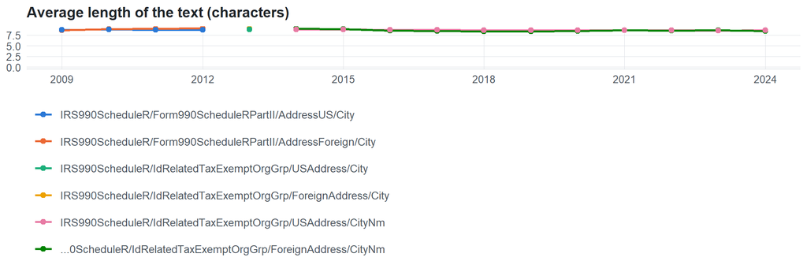

**Table view**

Table view: length and variety by tax year

| Series | Tax year | Filings | Avg length | Max length | Distinct values (approx.) |
| --- | --- | --- | --- | --- | --- |
| IRS990ScheduleR/Form990ScheduleRPartII/AddressUS/City | 2009 | 13,294 | 9 | 22 | 3,376 |
| IRS990ScheduleR/Form990ScheduleRPartII/AddressUS/City | 2010 | 33,609 | 9 | 22 | 3,496 |
| IRS990ScheduleR/Form990ScheduleRPartII/AddressUS/City | 2011 | 40,919 | 9 | 22 | 4,534 |
| IRS990ScheduleR/Form990ScheduleRPartII/AddressUS/City | 2012 | 44,490 | 9 | 22 | 4,083 |
| IRS990ScheduleR/Form990ScheduleRPartII/AddressForeign/City | 2009 | 156 | 9 | 30 | 102 |
| IRS990ScheduleR/Form990ScheduleRPartII/AddressForeign/City | 2010 | 376 | 9 | 34 | 249 |
| IRS990ScheduleR/Form990ScheduleRPartII/AddressForeign/City | 2011 | 492 | 9 | 35 | 276 |
| IRS990ScheduleR/Form990ScheduleRPartII/AddressForeign/City | 2012 | 560 | 9 | 34 | 337 |
| IRS990ScheduleR/IdRelatedTaxExemptOrgGrp/USAddress/City | 2013 | 47,596 | 9 | 22 | 3,533 |
| IRS990ScheduleR/IdRelatedTaxExemptOrgGrp/ForeignAddress/City | 2013 | 643 | 9 | 34 | 277 |
| IRS990ScheduleR/IdRelatedTaxExemptOrgGrp/USAddress/CityNm | 2014 | 51,116 | 9 | 22 | 4,640 |
| IRS990ScheduleR/IdRelatedTaxExemptOrgGrp/USAddress/CityNm | 2015 | 53,523 | 9 | 22 | 5,921 |
| IRS990ScheduleR/IdRelatedTaxExemptOrgGrp/USAddress/CityNm | 2016 | 55,448 | 9 | 22 | 8,222 |
| IRS990ScheduleR/IdRelatedTaxExemptOrgGrp/USAddress/CityNm | 2017 | 58,874 | 9 | 22 | 5,155 |
| IRS990ScheduleR/IdRelatedTaxExemptOrgGrp/USAddress/CityNm | 2018 | 59,172 | 9 | 22 | 6,330 |
| IRS990ScheduleR/IdRelatedTaxExemptOrgGrp/USAddress/CityNm | 2019 | 60,848 | 9 | 22 | 5,073 |
| IRS990ScheduleR/IdRelatedTaxExemptOrgGrp/USAddress/CityNm | 2020 | 65,651 | 9 | 22 | 5,398 |
| IRS990ScheduleR/IdRelatedTaxExemptOrgGrp/USAddress/CityNm | 2021 | 66,652 | 9 | 22 | 5,808 |
| IRS990ScheduleR/IdRelatedTaxExemptOrgGrp/USAddress/CityNm | 2022 | 67,472 | 9 | 22 | 7,545 |
| IRS990ScheduleR/IdRelatedTaxExemptOrgGrp/USAddress/CityNm | 2023 | 67,375 | 9 | 22 | 5,015 |
| IRS990ScheduleR/IdRelatedTaxExemptOrgGrp/USAddress/CityNm | 2024 | 45,159 | 9 | 22 | 4,608 |
| …0ScheduleR/IdRelatedTaxExemptOrgGrp/ForeignAddress/CityNm | 2014 | 734 | 9 | 35 | 432 |
| …0ScheduleR/IdRelatedTaxExemptOrgGrp/ForeignAddress/CityNm | 2015 | 811 | 9 | 35 | 466 |
| …0ScheduleR/IdRelatedTaxExemptOrgGrp/ForeignAddress/CityNm | 2016 | 860 | 9 | 32 | 772 |
| …0ScheduleR/IdRelatedTaxExemptOrgGrp/ForeignAddress/CityNm | 2017 | 976 | 8 | 32 | 631 |
| …0ScheduleR/IdRelatedTaxExemptOrgGrp/ForeignAddress/CityNm | 2018 | 1,061 | 8 | 34 | 716 |
| …0ScheduleR/IdRelatedTaxExemptOrgGrp/ForeignAddress/CityNm | 2019 | 1,146 | 8 | 35 | 567 |
| …0ScheduleR/IdRelatedTaxExemptOrgGrp/ForeignAddress/CityNm | 2020 | 1,262 | 8 | 35 | 564 |
| …0ScheduleR/IdRelatedTaxExemptOrgGrp/ForeignAddress/CityNm | 2021 | 1,287 | 9 | 33 | 874 |
| …0ScheduleR/IdRelatedTaxExemptOrgGrp/ForeignAddress/CityNm | 2022 | 1,348 | 9 | 34 | 1,149 |
| …0ScheduleR/IdRelatedTaxExemptOrgGrp/ForeignAddress/CityNm | 2023 | 1,362 | 9 | 31 | 696 |
| …0ScheduleR/IdRelatedTaxExemptOrgGrp/ForeignAddress/CityNm | 2024 | 894 | 8 | 30 | 556 |

Most common values by xpath (all years; long values truncated)

| Series | Value | Filings | Share |
| --- | --- | --- | --- |
| IRS990ScheduleR/Form990ScheduleRPartII/AddressUS/City | NEW YORK | 4,231 | 3.2% |
| IRS990ScheduleR/Form990ScheduleRPartII/AddressUS/City | WASHINGTON | 3,697 | 2.8% |
| IRS990ScheduleR/Form990ScheduleRPartII/AddressUS/City | COLUMBUS | 2,118 | 1.6% |
| IRS990ScheduleR/Form990ScheduleRPartII/AddressUS/City | PHILADELPHIA | 1,845 | 1.4% |
| IRS990ScheduleR/Form990ScheduleRPartII/AddressUS/City | CHICAGO | 1,737 | 1.3% |
| IRS990ScheduleR/Form990ScheduleRPartII/AddressUS/City | ST LOUIS | 1,476 | 1.1% |
| IRS990ScheduleR/Form990ScheduleRPartII/AddressUS/City | DENVER | 1,402 | 1.1% |
| IRS990ScheduleR/Form990ScheduleRPartII/AddressUS/City | BOSTON | 1,347 | 1.0% |
| IRS990ScheduleR/Form990ScheduleRPartII/AddressUS/City | INDIANAPOLIS | 1,028 | 0.8% |
| IRS990ScheduleR/Form990ScheduleRPartII/AddressUS/City | HOUSTON | 547 | 0.4% |
| IRS990ScheduleR/Form990ScheduleRPartII/AddressUS/City | LOS ANGELES | 452 | 0.3% |
| IRS990ScheduleR/Form990ScheduleRPartII/AddressUS/City | SPRINGFIELD | 389 | 0.3% |
| IRS990ScheduleR/Form990ScheduleRPartII/AddressUS/City | MILWAUKEE | 370 | 0.3% |
| IRS990ScheduleR/Form990ScheduleRPartII/AddressUS/City | Columbus | 213 | 0.2% |
| IRS990ScheduleR/Form990ScheduleRPartII/AddressUS/City | St Louis | 209 | 0.2% |
| IRS990ScheduleR/Form990ScheduleRPartII/AddressUS/City | Denver | 171 | 0.1% |
| IRS990ScheduleR/Form990ScheduleRPartII/AddressUS/City | Washington | 164 | 0.1% |
| IRS990ScheduleR/Form990ScheduleRPartII/AddressUS/City | New York | 162 | 0.1% |
| IRS990ScheduleR/Form990ScheduleRPartII/AddressForeign/City | LONDON | 124 | 7.8% |
| IRS990ScheduleR/Form990ScheduleRPartII/AddressForeign/City | FRANKFURT | 119 | 7.5% |
| IRS990ScheduleR/Form990ScheduleRPartII/AddressForeign/City | TORONTO | 78 | 4.9% |
| IRS990ScheduleR/Form990ScheduleRPartII/AddressForeign/City | PARIS | 67 | 4.2% |
| IRS990ScheduleR/Form990ScheduleRPartII/AddressForeign/City | Hamilton | 59 | 3.7% |
| IRS990ScheduleR/Form990ScheduleRPartII/AddressForeign/City | SAO PAULO | 52 | 3.3% |
| IRS990ScheduleR/Form990ScheduleRPartII/AddressForeign/City | NEW DELHI | 47 | 3.0% |
| IRS990ScheduleR/Form990ScheduleRPartII/AddressForeign/City | BUENOS AIRES | 46 | 2.9% |
| IRS990ScheduleR/Form990ScheduleRPartII/AddressForeign/City | London | 40 | 2.5% |
| IRS990ScheduleR/Form990ScheduleRPartII/AddressForeign/City | JERUSALEM | 39 | 2.5% |
| IRS990ScheduleR/Form990ScheduleRPartII/AddressForeign/City | NEW YORK | 12 | 0.8% |
| IRS990ScheduleR/Form990ScheduleRPartII/AddressForeign/City | nEW YORK | 10 | 0.6% |

First rows shown.

## Examples

| Tax year | Return | Xpath | Organization | Value | Source |
| --- | --- | --- | --- | --- | --- |
| 2024 | 990 | IRS990ScheduleR/IdRelatedTaxExemptOrgGrp/ForeignAddress/CityNm | ACCION INTERNATIONAL | BANGALORE | [XML](https://gt990datalake-rawdata.s3.amazonaws.com/EfileData/XmlFiles/202503189349301700_public.xml) |
| 2024 | 990 | IRS990ScheduleR/IdRelatedTaxExemptOrgGrp/USAddress/CityNm | RISEWELL COMMUNITY SERVICES INC FKA | WEST BABYLON | [XML](https://gt990datalake-rawdata.s3.amazonaws.com/EfileData/XmlFiles/202610589349301811_public.xml) |
| 2023 | 990 | IRS990ScheduleR/IdRelatedTaxExemptOrgGrp/ForeignAddress/CityNm | Harvard Real Estate - Allston Inc | MUMBAI | [XML](https://gt990datalake-rawdata.s3.amazonaws.com/EfileData/XmlFiles/202541359349307959_public.xml) |
| 2023 | 990 | IRS990ScheduleR/IdRelatedTaxExemptOrgGrp/USAddress/CityNm | ARIZONA YOUTH PARTNERSHIP | TUCSON | [XML](https://gt990datalake-rawdata.s3.amazonaws.com/EfileData/XmlFiles/202510809349301201_public.xml) |
| 2022 | 990 | IRS990ScheduleR/IdRelatedTaxExemptOrgGrp/ForeignAddress/CityNm | BAKERSFIELD MEMORIAL HOSPITAL | NUNNEY | [XML](https://gt990datalake-rawdata.s3.amazonaws.com/EfileData/XmlFiles/202411229349303201_public.xml) |
| 2022 | 990 | IRS990ScheduleR/IdRelatedTaxExemptOrgGrp/USAddress/CityNm | HARI AND ANJALI AGRAWAL CHARITABLE FDN | ALPHARETTA | [XML](https://gt990datalake-rawdata.s3.amazonaws.com/EfileData/XmlFiles/202343159349301744_public.xml) |
| 2021 | 990 | IRS990ScheduleR/IdRelatedTaxExemptOrgGrp/ForeignAddress/CityNm | BAR ILAN UNIVERSITY IN ISRAEL INC | RAMAT GAN | [XML](https://gt990datalake-rawdata.s3.amazonaws.com/EfileData/XmlFiles/202322269349302912_public.xml) |
| 2021 | 990 | IRS990ScheduleR/IdRelatedTaxExemptOrgGrp/USAddress/CityNm | CAMP JOHN MARC FOUNDATION INC | DALLAS | [XML](https://gt990datalake-rawdata.s3.amazonaws.com/EfileData/XmlFiles/202241039349300339_public.xml) |
| 2020 | 990 | IRS990ScheduleR/IdRelatedTaxExemptOrgGrp/ForeignAddress/CityNm | KILIMANJARO TECHNOLOGY FOUNDATION | ARUSHA | [XML](https://gt990datalake-rawdata.s3.amazonaws.com/EfileData/XmlFiles/202141329349301419_public.xml) |
| 2020 | 990 | IRS990ScheduleR/IdRelatedTaxExemptOrgGrp/USAddress/CityNm | The CareSource Foundation | Dayton | [XML](https://gt990datalake-rawdata.s3.amazonaws.com/EfileData/XmlFiles/202123169349306582_public.xml) |
| 2019 | 990 | IRS990ScheduleR/IdRelatedTaxExemptOrgGrp/ForeignAddress/CityNm | THE KISSING WELL NFP | KAMPALA | [XML](https://gt990datalake-rawdata.s3.amazonaws.com/EfileData/XmlFiles/202033089349301003_public.xml) |
| 2019 | 990 | IRS990ScheduleR/IdRelatedTaxExemptOrgGrp/USAddress/CityNm | Chauffeurs Teamsters & Helpers Local 878 | Little Rock | [XML](https://gt990datalake-rawdata.s3.amazonaws.com/EfileData/XmlFiles/202043219349315409_public.xml) |

## Reviewer checklist

- The definition matches the form line and instructions for every xpath’s schema years.
- Every xpath pooled here measures the same thing on the 990 and 990-EZ (close enough for analysis).
- The coverage chart has no unexplained gaps or jumps between tax years.
- Each open flag is fixed, or accepted with a note in validation_log.csv.
- Values answer the question on the form line (not another line’s explanation).
- Boilerplate such as ‘See Schedule O’ or ‘N/A’ is expected here, or should be treated as missing.
- Text that is really a number or a code is flagged for a different data type.

Record the review as a row in `inst/extdata/src/validation_log.csv` (variable_name, reviewer, date, status, note). Evidence built 2026-09-23 17:09:04 MST from the ef2 DuckDB builds (tax years 2009–2024).